# Step1. QC

Sujin Seo (sujin91kr@gmail.com)

2023-12-14

### Data description

Blood samples were extracted from 60 individuals, 34 are controls and 26 are cases and three sets of files are provided.  
- Methylation data : EPIC BeadChip 850K (Illumina) (.idat files in idats folder)  
- SNP data : Korean Chip (Affymetix) - (.txt files in SNPdata folder)  
- Phenoypte data : Disease, Age, Sex (Pheno.csv)

### Load required libraries

```r
library(ewastools)
library(svd)
library(data.table)
library(dplyr)
library(lumi)
```

### Load data

```r
### Read phenotype data
pheno <- read.table("Pheno.csv", sep = ",", header = T, stringsAsFactors = F) %>% as.data.table()
head(pheno)
```

```
##     SampleID Disease Age Sex
## 1: Control_1       0  71   F
## 2: Control_2       0  58   M
## 3: Control_3       0  73   M
## 4: Control_4       0  73   M
## 5: Control_5       0  56   M
## 6: Control_6       0  60   M
```

`pheno` contains columns named *SampleID*, *Diseae*, *Age* and *Sex*. *SampleID* represents the prefix of the methylation file names(.idat) and Sample ID of SNP data. *Disease* contains 0 or 1, which represents control and case, respectively.

```r
### Read methylation data
meth <- read_idats(paste0("idats/", pheno$SampleID), quiet = TRUE)
```

```
## [1] 1051815
```

```r
str(meth)
```

```
## List of 15
##  $ platform: chr "EPIC"
##  $ manifest:Classes 'data.table' and 'data.frame':   865918 obs. of  13 variables:
##   ..$ probe_id  : chr [1:865918] "rs10796216" "rs2468330" "rs213028" "rs951295" ...
##   ..$ addressU  : int [1:865918] 84632581 55653201 31661197 1777132 79696145 62607574 56780575 76700477 60714280 3675120 ...
##   ..$ addressM  : int [1:865918] 77745366 NA 3637210 81605941 NA 25691590 NA NA NA 63782162 ...
##   ..$ channel   : chr [1:865918] "Red" "Both" "Red" "Grn" ...
##   ..$ next_base : chr [1:865918] "A" "" "T" "C" ...
##   ..$ chr       : chr [1:865918] "" "" "" "" ...
##   ..$ mapinfo   : int [1:865918] NA NA NA NA NA NA NA NA NA NA ...
##   ..$ strand    : Factor w/ 3 levels "","F","R": 1 1 1 1 1 1 1 1 1 1 ...
##   ..$ probe_type: chr [1:865918] "rs" "rs" "rs" "rs" ...
##   ..$ index     : int [1:865918] 1 2 3 4 5 6 7 8 9 10 ...
##   ..$ OOBi      : int [1:865918] 1 NA 2 1 NA 3 NA NA NA 4 ...
##   ..$ Ui        : int [1:865918] 838118 536579 317324 11371 774881 597919 551235 733976 584070 32239 ...
##   ..$ Mi        : int [1:865918] 750746 536579 29821 796811 774881 263749 551235 733976 584070 613991 ...
##   ..- attr(*, ".internal.selfref")=<externalptr>
##   ..- attr(*, "sorted")= chr [1:2] "chr" "mapinfo"
##   ..- attr(*, "index")= int(0)
##   .. ..- attr(*, "__channel")= int [1:865918] 2 5 7 8 9 11 12 15 17 18 ...
##  $ U       : num [1:865918, 1:60] 18005 13509 18091 11988 23002 ...
##  $ T       : int [1:865918, 1:60] 1946 1397 1114 1479 784 521 1399 356 1898 1020 ...
##  $ V       : int [1:865918, 1:60] 18 11 10 14 9 11 14 11 16 16 ...
##  $ M       : num [1:865918, 1:60] 740 6404 18005 600 325 ...
##  $ S       : int [1:865918, 1:60] 482 706 1656 149 270 2311 234 617 91 1543 ...
##  $ N       : int [1:865918, 1:60] 12 11 12 12 9 17 14 11 16 20 ...
##  $ controls:Classes 'data.table' and 'data.frame':   635 obs. of  6 variables:
##   ..$ address: int [1:635] 21630339 24669308 27630314 34648333 41666334 43603326 12719506 21752326 63642461 74666473 ...
##   ..$ group  : chr [1:635] "STAINING" "STAINING" "STAINING" "STAINING" ...
##   ..$ channel: chr [1:635] "-99" "-99" "Red" "Blue" ...
##   ..$ name   : chr [1:635] "DNP(20K)" "Biotin(5K)" "DNP (High)" "Biotin (Bkg)" ...
##   ..$ index  : int [1:635] 1 2 3 4 5 6 7 8 9 10 ...
##   ..$ i      : int [1:635] 224717 253541 279630 343698 408403 423978 146415 230003 608034 707200 ...
##   ..- attr(*, ".internal.selfref")=<externalptr>
##  $ ctrlG   : num [1:635, 1:60] 312 17124 372 294 24896 ...
##  $ ctrlR   : num [1:635, 1:60] 45414 651 43242 581 1983 ...
##  $ ctrlN   : int [1:635, 1:60] 53 37 77 60 5 43 90 77 88 87 ...
##  $ oobG    :List of 2
##   ..$ M: num [1:92212, 1:60] 363 433 383 294 294 642 321 260 283 336 ...
##   ..$ U: num [1:92212, 1:60] 419 415 293 272 355 529 242 202 470 267 ...
##  $ oobR    :List of 2
##   ..$ M: num [1:49946, 1:60] 810 791 1226 546 1442 ...
##   ..$ U: num [1:49946, 1:60] 1775 943 677 458 1545 ...
##  $ meta    :Classes 'data.table' and 'data.frame':   60 obs. of  5 variables:
##   ..$ sample_id: chr [1:60] "Control_1" "Control_2" "Control_3" "Control_4" ...
##   ..$ date     : IDate[1:60], format: NA NA ...
##   ..$ time     : 'ITime' int [1:60] NA NA NA NA NA NA NA NA NA NA ...
##   ..$ barcode  : chr [1:60] "202410160120" "202410280067" "202410160173" "202702320203" ...
##   ..$ position : chr [1:60] "R07C01" "R03C01" "R06C01" "R06C01" ...
##   ..- attr(*, ".internal.selfref")=<externalptr>
```

Each sample has two color channels, red and green, and each channel has its own .idat file. Using `read_idats` with sample ID, methylation data can be imported into R.

### Preprocess

```r
beta = meth %>% detectionP %>% mask(0.01) %>% correct_dye_bias %>% dont_normalize
```

- `detectionP` : Calculate detection p-values to filter out unreliable data point due to the low fluorescence intensities.
- `mask` : Significance level fo detectionP. Probes above this threshold are set to missing.
- `correct_dye_bias` : Normalize the red and green color channel.
- `dont_normalize` : Beta value without normalization to prevent removal of biological signal.

### Quality Controls

#### (1) Control metrics

```r
cntrls <- control_metrics(meth)
pheno$failed <- sample_failure(cntrls)
table(pheno$failed)
```

```
##
## FALSE
##    60
```

```r
pheno[failed == TRUE, exclude := TRUE]
```

`control_metrics` provides 17 control metrics and each value is described in [BeadArray Controls Reporter](https://support.illumina.com/content/dam/illumina-support/documents/documentation/chemistry_documentation/infinium_assays/infinium_hd_methylation/beadarray-controls-reporter-user-guide-1000000004009-00.pdf). `sample_failure` evaluates the 17 metrics against their thresholds and returns passed or failed. In our data, all sample are passed the control metrics.

#### (2) Sex mismatches

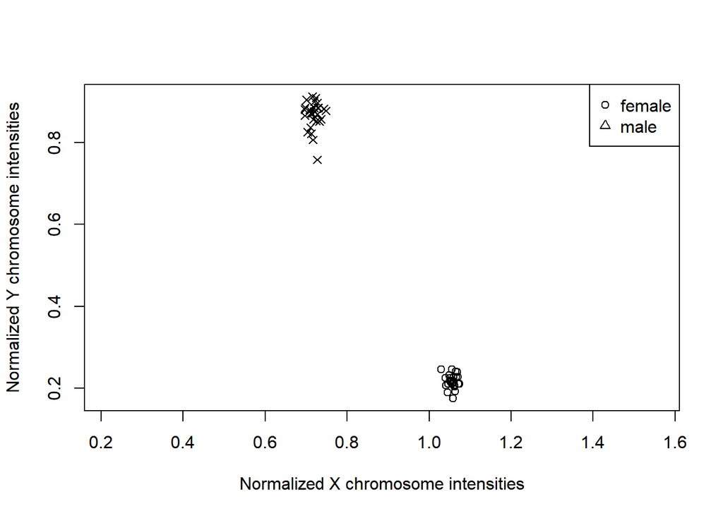

```r
xy_int <- check_sex(meth %>% correct_dye_bias) # Normalized average intensity of X, Y chr
pheno$pred_sex <- predict_sex(xy_int$X, xy_int$Y)
pheno[Sex!=toupper(pred_sex), exclude := TRUE]

plot(xy_int$X, xy_int$Y, pch = ifelse(pheno$pred_sex =="f", 1, 4), asp = 1,
     xlab = "Normalized X chromosome intensities",
     ylab = "Normalized Y chromosome intensities")
legend("topright", pch = c(1,2), legend = c("female", "male"))
```

```r
table(pheno$Sex, pheno$pred_sex)
```

```
##
##      m  f
##   F  0 30
##   M 30  0
```

`check_sex` calculates the normalized average intensity of X and Y chromosome and `predict_sex` infers sex. Then, comparing with the known sex information, we identify mislabeled samples.

#### (3) Genotype calling and outliers

```r
manifest <- meth$manifest
head(manifest)
```

```
##      probe_id addressU addressM channel next_base chr mapinfo strand probe_type
## 1: rs10796216 84632581 77745366     Red         A          NA                rs
## 2:  rs2468330 55653201       NA    Both                    NA                rs
## 3:   rs213028 31661197  3637210     Red         T          NA                rs
## 4:   rs951295  1777132 81605941     Grn         C          NA                rs
## 5:   rs877309 79696145       NA    Both                    NA                rs
## 6:  rs3936238 62607574 25691590     Red         T          NA                rs
##    index OOBi     Ui     Mi
## 1:     1    1 838118 750746
## 2:     2   NA 536579 536579
## 3:     3    2 317324  29821
## 4:     4    1  11371 796811
## 5:     5   NA 774881 774881
## 6:     6    3 597919 263749
```

```r
unique(manifest$probe_type)
```

```
## [1] "rs" "cg" "ch"
```

```r
snps_index = manifest[probe_type == "rs", index]
snps = beta[snps_index,]
genotypes = call_genotypes(snps)
pheno$outliers = snp_outliers(genotypes)
pheno[outliers>-4, exclude := TRUE]
```

`call_genotypes` estimates the parmeters of three mixture models of beta distributsion: one heterozygous and two homozygous genotypes. Genotypes of contaminiated samples deviate from the ideal trimodal distribution, and this deviation is calculated for each SNP. `snp_outliers` averages the values across all SNPs and gives the log2 odds of being an outlier. The score > -4 is recommended for exclusion.

#### (4) PCA

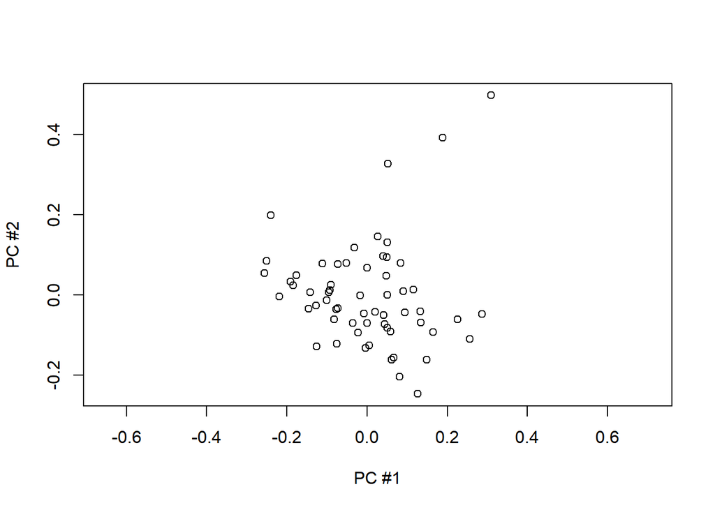

```r
xy_index = manifest[chr %in% c("X", "Y") & probe_type != "rs", index]
pcs = beta[-xy_index,]
pcs = pcs - rowMeans(pcs)
pcs = na.omit(pcs)
pcs = t(pcs)
pcs = trlan.svd(pcs,neig=2) # compute the first two principal components
pcs = pcs$u

pheno$pc1 = pcs[,1]
pheno$pc2 = pcs[,2]

plot(pc2 ~ pc1,pheno,asp=1,xlab="PC #1",ylab="PC #2")
```

#### (5) Leukcyte estimation

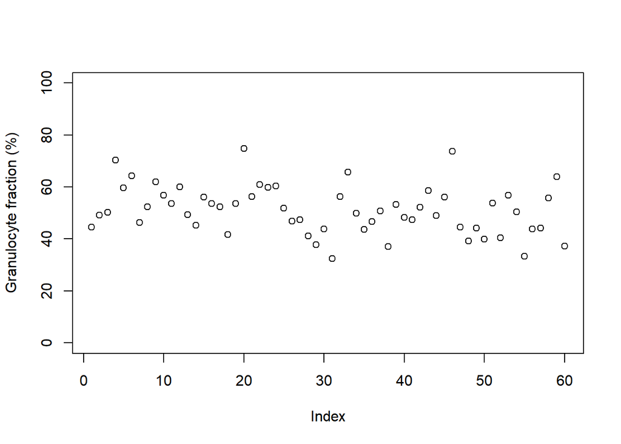

```r
lc <- estimateLC(beta, ref="deGoede+Reinius")
pheno <- cbind(pheno, lc)

plot(pheno$GR*100,ylab="Granulocyte fraction (%)", ylim = c(0, 100))
```

Methylation level of blood are vary by leukocyte composition and they are estimated by [Housman](https://bmcbioinformatics.biomedcentral.com/articles/10.1186/1471-2105-13-86) method using `estimateLC`. Prominently different samples from others could be excluded in the analysis.

#### (6) Probe call rate

```r
probe_callrate <- apply(beta, 1, function(x) 1-sum(is.na(x))/length(x))
beta <- beta[probe_callrate >= 0.95, ]
```

Probes with a call rate <95% are removed.

### Extract samples/CpG

```r
drop  = pheno[exclude==TRUE,which=TRUE]
if (length(drop) > 1) {
  pheno = pheno[ -drop]
  beta  = beta [,-drop]
  meth <- meth %>% drop_samples(j=drop)
}

manifest <- meth$manifest %>% filter(probe_id %in% rownames(beta)) %>% data.frame()
rownames(manifest) <- manifest$probe_id

cpg = manifest[manifest$probe_type == "cg", "probe_id"]
autosome = manifest[!manifest$chr %in% c('X', 'Y'), "probe_id"]
ewas_cpg <- intersect(cpg, autosome)

beta <- beta[ewas_cpg,]
manifest <- manifest[ewas_cpg,]
```

Problematic samples/probes are removed. Additionally, probes of only ‘cg’ type of autosome are remained for EWAS.

### Convert Beta-value to M-value

```r
mvalue <- beta2m(beta)
```

### Export outputs

```r
write.table(pheno, "01_Pheno_QCed.csv", sep = ",", col.names = T, row.names = F, quote = F)
save(mvalue, file = "01_Mvalue_QCed.RData")
write.table(meth$manifest, "01_Manifest_QCed.csv", sep = ",", col.names = T, row.names = F, quote = F)
```

**Reference**  
1. Heiss, J. A., & Just, A. C. (2018). Identifying mislabeled and contaminated DNA methylation microarray data: an extended quality control toolset with examples from GEO. Clinical epigenetics, 10(1), 1-9  
2. https://hhhh5.github.io/ewastools/articles/exemplary_ewas.html  
3. https://www.epicenteredresearch.com/pace/qcsteps/